# Statistical Modeling and Analysis

Kalu Minale, Byeolha Kim, Shine Ha Neul Chang, Leah R Davis

2024-12-05

Load in the dataset

```r
marathon_dataset<-read.csv("../data_raw/boston_marathon_2023.csv")

head(marathon_dataset)
```

```
##   age_group place_overall place_gender place_division            name  team
## 1     18-39             1            1              1   Chebet, Evans Team–
## 2     18-39             2            2              2   Geay, Gabriel Team–
## 3     18-39             3            3              3 Kipruto, Benson Team–
## 4     18-39             4            4              4   Korir, Albert Team–
## 5     18-39             5            5              5  Talbi, Zouhair Team–
## 6     18-39             6            6              6 Kipchoge, Eliud Team–
##   bib_number half_time finish_net finish_gun gender half_time_sec
## 1          1 1H 2M 20S  2H 5M 54S  2H 5M 54S      M          3740
## 2          3 1H 2M 20S   2H 6M 4S   2H 6M 4S      M          3740
## 3          5 1H 2M 19S   2H 6M 6S   2H 6M 6S      M          3739
## 4         19 1H 2M 20S   2H 8M 1S   2H 8M 1S      M          3740
## 5         31 1H 2M 20S  2H 8M 35S  2H 8M 35S      M          3740
## 6          2 1H 2M 19S  2H 9M 23S  2H 9M 23S      M          3739
##   finish_net_sec finish_gun_sec finish_net_minutes
## 1           7554           7554           125.9000
## 2           7564           7564           126.0667
## 3           7566           7566           126.1000
## 4           7681           7681           128.0167
## 5           7715           7715           128.5833
## 6           7763           7763           129.3833
```

Finish_net has it’s time in (Num Hours Num Minutes Num Seconds) We want it in only integers

```r
library(stringr)

marathon_dataset$finish_net_seconds <- marathon_dataset$finish_net %>%
  str_match("([0-9]+)H ([0-9]+)M ([0-9]+)S") %>%
  as.data.frame() %>%
  transform(
    hours = as.numeric(V2),  #
    minutes = as.numeric(V3),
    seconds = as.numeric(V4)
  ) %>%
  with(hours * 3600 + minutes * 60 + seconds)
head(marathon_dataset$finish_net_seconds)
```

```
## [1] 7554 7564 7566 7681 7715 7763
```

```r
marathon_dataset$finish_net_minutes <- marathon_dataset$finish_net_seconds / 60
marathon_dataset$finish_net_hours <- marathon_dataset$finish_net_seconds / 3600
```

```r
is.numeric(marathon_dataset$finish_net_sec)      # Should return TRUE
```

```
## [1] TRUE
```

```r
is.numeric(marathon_dataset$finish_net_minutes)
```

```
## [1] TRUE
```

Remove Rows with Missing or Invalid Values

```r
marathon_dataset <- marathon_dataset[!is.na(marathon_dataset$finish_net) &
                                     !is.na(marathon_dataset$finish_net_minutes) &
                                     !is.na(marathon_dataset$finish_net_sec), ]

is.numeric(marathon_dataset$finish_net)
```

```
## [1] FALSE
```

```r
is.numeric(marathon_dataset$finish_net_minutes)
```

```
## [1] TRUE
```

```r
is.numeric(marathon_dataset$finish_net_sec)
```

```
## [1] TRUE
```

Linear Regression Model predicting `finish_time` based on `age` and `gender`

```r
#We want to convert the age groups into categorical variabels because its age groups
marathon_dataset$age_group <- as.factor(marathon_dataset$age_group)

lm_model_minutes <- lm(finish_net_minutes ~ age_group * gender, data = marathon_dataset)

lm_model_seconds <- lm(finish_net_sec ~ age_group * gender, data = marathon_dataset)

# Summaries of the models
summary(lm_model_minutes)
```

```
##
## Call:
## lm(formula = finish_net_minutes ~ age_group * gender, data = marathon_dataset)
##
## Residuals:
##    Min     1Q Median     3Q    Max
## -86.27 -25.20 -12.70  13.39 212.61
##
## Coefficients:
##                        Estimate Std. Error t value Pr(>|t|)
## (Intercept)            196.5062     0.5398 364.040  < 2e-16 ***
## age_group40-44           6.4956     0.9891   6.567 5.23e-11 ***
## age_group45-49          13.7501     0.9874  13.925  < 2e-16 ***
## age_group50-54          24.8139     1.0206  24.312  < 2e-16 ***
## age_group55-59          31.7800     1.1722  27.111  < 2e-16 ***
## age_group60-64          43.3035     1.2955  33.425  < 2e-16 ***
## age_group65-69          56.4405     1.7595  32.078  < 2e-16 ***
## age_group70-74          73.6749     2.7422  26.867  < 2e-16 ***
## age_group75-79          99.8101     5.6314  17.724  < 2e-16 ***
## age_group80+           101.3993    22.6606   4.475 7.68e-06 ***
## genderW                 31.3995     0.7789  40.315  < 2e-16 ***
## age_group40-44:genderW  -3.6588     1.4538  -2.517 0.011851 *
## age_group45-49:genderW  -5.7847     1.4621  -3.957 7.62e-05 ***
## age_group50-54:genderW  -8.1128     1.6225  -5.000 5.77e-07 ***
## age_group55-59:genderW  -6.4071     1.8917  -3.387 0.000708 ***
## age_group60-64:genderW -12.3126     2.2170  -5.554 2.82e-08 ***
## age_group65-69:genderW -12.2452     3.2214  -3.801 0.000144 ***
## age_group70-74:genderW  -8.1804     5.7156  -1.431 0.152373
## age_group75-79:genderW -31.3508    13.6379  -2.299 0.021524 *
## age_group80+:genderW   -23.4050    35.8279  -0.653 0.513592
## ---
## Signif. codes:  0 '***' 0.001 '**' 0.01 '*' 0.05 '.' 0.1 ' ' 1
##
## Residual standard error: 39.24 on 26578 degrees of freedom
## Multiple R-squared:  0.1964, Adjusted R-squared:  0.1958
## F-statistic: 341.8 on 19 and 26578 DF,  p-value: < 2.2e-16
```

```r
summary(lm_model_seconds)
```

```
##
## Call:
## lm(formula = finish_net_sec ~ age_group * gender, data = marathon_dataset)
##
## Residuals:
##     Min      1Q  Median      3Q     Max
## -5176.3 -1511.7  -761.9   803.4 12756.7
##
## Coefficients:
##                        Estimate Std. Error t value Pr(>|t|)
## (Intercept)            11790.37      32.39 364.040  < 2e-16 ***
## age_group40-44           389.74      59.35   6.567 5.23e-11 ***
## age_group45-49           825.01      59.25  13.925  < 2e-16 ***
## age_group50-54          1488.83      61.24  24.312  < 2e-16 ***
## age_group55-59          1906.80      70.33  27.111  < 2e-16 ***
## age_group60-64          2598.21      77.73  33.425  < 2e-16 ***
## age_group65-69          3386.43     105.57  32.078  < 2e-16 ***
## age_group70-74          4420.49     164.53  26.867  < 2e-16 ***
## age_group75-79          5988.61     337.88  17.724  < 2e-16 ***
## age_group80+            6083.96    1359.64   4.475 7.68e-06 ***
## genderW                 1883.97      46.73  40.315  < 2e-16 ***
## age_group40-44:genderW  -219.53      87.23  -2.517 0.011851 *
## age_group45-49:genderW  -347.08      87.72  -3.957 7.62e-05 ***
## age_group50-54:genderW  -486.77      97.35  -5.000 5.77e-07 ***
## age_group55-59:genderW  -384.43     113.50  -3.387 0.000708 ***
## age_group60-64:genderW  -738.76     133.02  -5.554 2.82e-08 ***
## age_group65-69:genderW  -734.71     193.29  -3.801 0.000144 ***
## age_group70-74:genderW  -490.82     342.93  -1.431 0.152373
## age_group75-79:genderW -1881.05     818.27  -2.299 0.021524 *
## age_group80+:genderW   -1404.30    2149.67  -0.653 0.513592
## ---
## Signif. codes:  0 '***' 0.001 '**' 0.01 '*' 0.05 '.' 0.1 ' ' 1
##
## Residual standard error: 2354 on 26578 degrees of freedom
## Multiple R-squared:  0.1964, Adjusted R-squared:  0.1958
## F-statistic: 341.8 on 19 and 26578 DF,  p-value: < 2.2e-16
```

Box Plot for Model Above

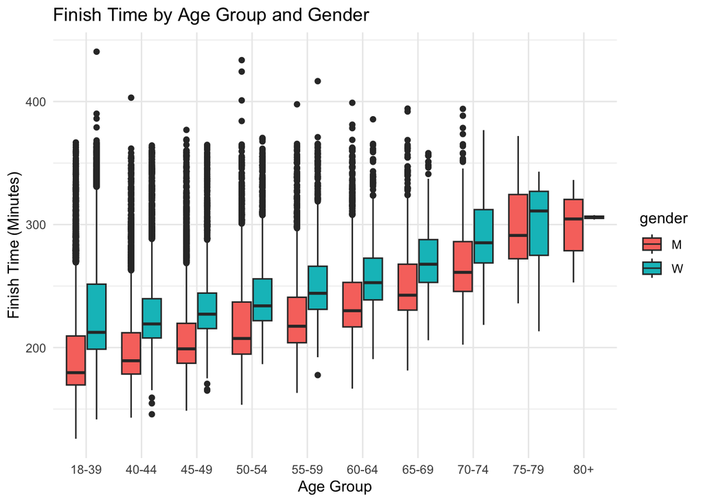

```r
library(ggplot2)
# Boxplot for finish time in minutes by age group and gender

ggplot(marathon_dataset, aes(x = age_group, y = finish_net_minutes, fill = gender)) +
  geom_boxplot() +
  labs( title = "Finish Time by Age Group and Gender",
        x = "Age Group",
        y = "Finish Time (Minutes)" ) +
  theme_minimal()
```

Bar Chart: Gender Distribution by Age Group

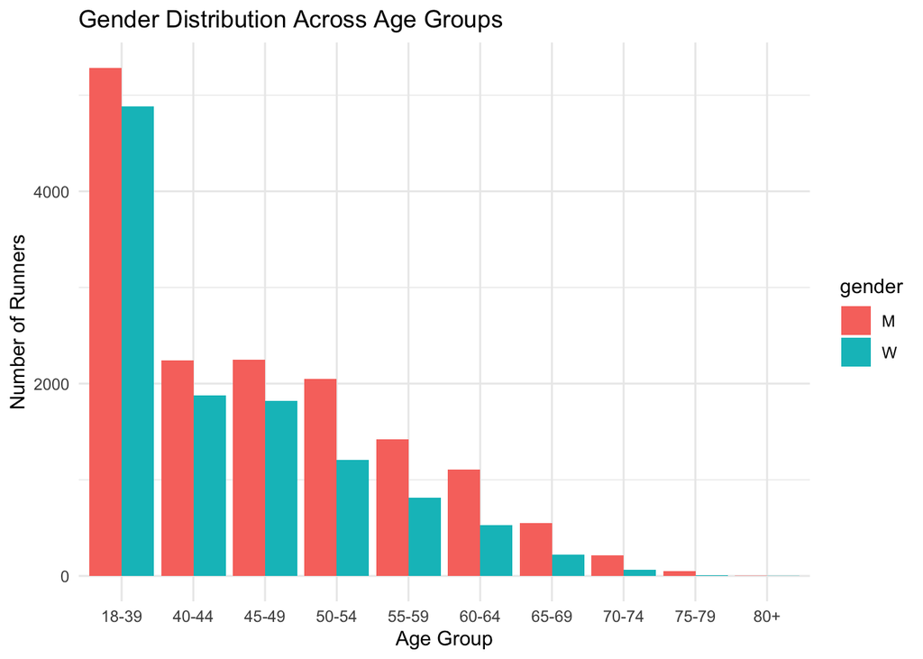

```r
# Count data
age_gender_counts <- table(marathon_dataset$age_group, marathon_dataset$gender)

# Bar chart
ggplot(marathon_dataset, aes(x = age_group, fill = gender)) +
  geom_bar(position = "dodge") +
  labs(
    title = "Gender Distribution Across Age Groups",
    x = "Age Group",
    y = "Number of Runners"
  ) +
  theme_minimal()
```

Table: Gender Counts by Age Group

```r
# Table of counts
gender_age_summary <- as.data.frame(age_gender_counts)
colnames(gender_age_summary) <- c("Age_Group", "Gender", "Count")
print(gender_age_summary)
```

```
##    Age_Group Gender Count
## 1      18-39      M  5284
## 2      40-44      M  2241
## 3      45-49      M  2252
## 4      50-54      M  2052
## 5      55-59      M  1422
## 6      60-64      M  1110
## 7      65-69      M   549
## 8      70-74      M   213
## 9      75-79      M    49
## 10       80+      M     3
## 11     18-39      W  4884
## 12     40-44      W  1878
## 13     45-49      W  1817
## 14     50-54      W  1207
## 15     55-59      W   815
## 16     60-64      W   527
## 17     65-69      W   221
## 18     70-74      W    62
## 19     75-79      W    10
## 20       80+      W     2
```

Lets try to see which gender seems to age more gracefully in their running?

```r
filtered_data <- marathon_dataset[marathon_dataset$age_group %in% c("50-54", "55-59", "60-64", "65-69", "70-74", "75-79", "80+"), ]

#Creating the avg times for older runners
library(dplyr)
average_times <- filtered_data %>%
  group_by(age_group, gender) %>%
  summarize(average_finish_minutes = mean(finish_net_minutes, na.rm = TRUE), .groups = "drop") %>%
  arrange(age_group, gender)

print(average_times)
```

```
## # A tibble: 14 × 3
##    age_group gender average_finish_minutes
##    <fct>     <chr>                   <dbl>
##  1 50-54     M                        221.
##  2 50-54     W                        245.
##  3 55-59     M                        228.
##  4 55-59     W                        253.
##  5 60-64     M                        240.
##  6 60-64     W                        259.
##  7 65-69     M                        253.
##  8 65-69     W                        272.
##  9 70-74     M                        270.
## 10 70-74     W                        293.
## 11 75-79     M                        296.
## 12 75-79     W                        296.
## 13 80+       M                        298.
## 14 80+       W                        306.
```

Now lets see if we can get a visual for this?

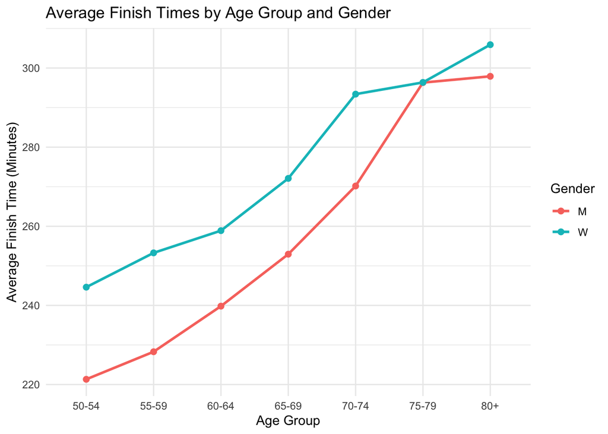

```r
#Line plot will serve the best for this specific task
ggplot(average_times, aes(x = age_group, y = average_finish_minutes, color = gender, group = gender)) +
  geom_line(size = 1) +
  geom_point(size = 2) +
  labs(
    title = "Average Finish Times by Age Group and Gender",
    x = "Age Group",
    y = "Average Finish Time (Minutes)",
    color = "Gender"
  ) +
  theme_minimal()
```

To really know for certain lets investigate statistically.

Creating a t-test may be the best for this:

```r
library(dplyr)

filtered_data <- marathon_dataset %>%
  filter(age_group %in% c("50-54", "55-59", "60-64", "65-69", "70-74", "75-79", "80+"))

#Performing the t-test
t_test_results <- filtered_data %>%
  group_by(age_group) %>%
  summarize(
    t_stat = t.test(finish_net_minutes[gender == "M"], finish_net_minutes[gender == "W"], var.equal = FALSE)$statistic,
    p_value = format(t.test(finish_net_minutes[gender == "M"], finish_net_minutes[gender == "W"], var.equal = FALSE)$p.value, scientific = FALSE)
  )

print(t_test_results)
```

```
## # A tibble: 7 × 3
##   age_group    t_stat p_value
##   <fct>         <dbl> <chr>
## 1 50-54     -17.3     0.0000000000000000000000000000000000000000000000000000000…
## 2 55-59     -15.9     0.0000000000000000000000000000000000000000000000000000436…
## 3 60-64     -10.8     0.00000000000000000000000003942629
## 4 65-69      -7.41    0.0000000000005726818
## 5 70-74      -4.49    0.00001804519
## 6 75-79      -0.00320 0.997503
## 7 80+        -0.328   0.7735721
```

Here we see that the p values for ages 50-74 the p-values are less than 0.05 which tells us that there is a statistically significant difference between the finish times of older men versus older women. However, when we go even higher in age (75-80+) the p-value becomes higher than 0.05 which means that the performances and differences in times aren’t statistically significant enough to make a difference in average.

This supports what we implied earlier with how it seems that as runners begin to age more, the performance between the two genders start to get closer together.

Now, lets say someone was given their bib number for the race. The Boston Athletic Association (B.A.A) assigns every year assigns numbers based on qualifying times. If someone were superstitious about the number they were assigned and how well they do: are they reasonable in this belief?

Some runners didn’t have a bib_number so we’ll need to cut some rows first:

```r
# Identify rows where bib_number is non-numeric
problematic_rows <- filtered_data[is.na(as.numeric(as.character(filtered_data$bib_number))), ]
print(problematic_rows)
```

```
##      age_group place_overall place_gender place_division
## 3010     55-59         17503        11116            958
## 3509     60-64          6585         5804             35
## 3761     60-64         14278         9790            287
## 5122     65-69         26299        15032            538
## 6705     55-59         15452         5178            100
## 7811     60-64         22831         9361            391
##                         name  team bib_number  half_time finish_net finish_gun
## 3010         Bertanza, Luigi Team–       P122  1H 50M 4S 3H 50M 43S 3H 50M 43S
## 3509 Hupe, Johannes-Reinhard Team–       P113 1H 33M 12S 3H 10M 46S 3H 10M 46S
## 3761          Lavoie, Dennis Team–       P116 1H 46M 36S 3H 37M 21S 3H 37M 21S
## 5122 Tortini, Giuseppe Maria Team–       P127 2H 32M 43S 5H 47M 17S 5H 47M 17S
## 6705          Thompson, Lisa Team–       P143 1H 48M 27S  3H 42M 0S  3H 42M 0S
## 7811             Cron, Joyce Team–       P146 2H 13M 40S 4H 31M 14S 4H 31M 14S
##      gender half_time_sec finish_net_sec finish_gun_sec finish_net_minutes
## 3010      M          6604          13843          13843           230.7167
## 3509      M          5592          11446          11446           190.7667
## 3761      M          6396          13041          13041           217.3500
## 5122      M          9163          20837          20837           347.2833
## 6705      W          6507          13320          13320           222.0000
## 7811      W          8020          16274          16274           271.2333
##      finish_net_seconds finish_net_hours
## 3010              13843         3.845278
## 3509              11446         3.179444
## 3761              13041         3.622500
## 5122              20837         5.788056
## 6705              13320         3.700000
## 7811              16274         4.520556
```

```r
filtered_data <- filtered_data %>%
  filter(!is.na(as.numeric(as.character(bib_number))))
```

Now we can proceed by creating a linear regression model:

```r
#Firstly lets make sure bib_number will be numeric
filtered_data$bib_number <- as.numeric(as.character(filtered_data$bib_number))

#Then we'll create the model
lm_model <- lm(finish_net_minutes ~ bib_number, data = filtered_data)
summary(lm_model)
```

```
##
## Call:
## lm(formula = finish_net_minutes ~ bib_number, data = filtered_data)
##
## Residuals:
##     Min      1Q  Median      3Q     Max
## -92.992 -17.710  -6.692  10.028 241.655
##
## Coefficients:
##              Estimate Std. Error t value Pr(>|t|)
## (Intercept) 1.619e+02  9.538e-01  169.79   <2e-16 ***
## bib_number  3.983e-03  4.592e-05   86.74   <2e-16 ***
## ---
## Signif. codes:  0 '***' 0.001 '**' 0.01 '*' 0.05 '.' 0.1 ' ' 1
##
## Residual standard error: 29.17 on 8234 degrees of freedom
## Multiple R-squared:  0.4775, Adjusted R-squared:  0.4774
## F-statistic:  7524 on 1 and 8234 DF,  p-value: < 2.2e-16
```

There are a couple of things to note here: -The p-value is <2.2e-16 which tells us that bib number and finish time has a statistically significant relationship here. -R^2 is 0.4774 which means almost half the variance is explained by the bib number. -F-statistic is 7524 with the earlier p-value being < 2e-16 means this model is significant

The coefficient being positive for bib numbers does support the idea that higher bib numbers lead to slower finish times. This work with how the system is in place: Runners when signing up for the marathon are to submit to a 12-month qualification period where they need to achieve a qualifying time to be eligible to run the race in April. Those with the fastest times are deemed elite runners and are given a lower bib number as a result. The model here does highlight this system. Bib numbers are VERY important for health reasons and even for teams of sports analysis who only want to analyze the best athletes.

Lets continue this investigation of bib number by comparing it with placement overall in the race:

```r
# Model of place and bib number
lm_model <- lm(place_overall ~ bib_number, data = filtered_data)
summary(lm_model)
```

```
##
## Call:
## lm(formula = place_overall ~ bib_number, data = filtered_data)
##
## Residuals:
##    Min     1Q Median     3Q    Max
## -17471  -2566   -252   2185  22260
##
## Coefficients:
##              Estimate Std. Error t value Pr(>|t|)
## (Intercept) 3.431e+03  1.236e+02   27.77   <2e-16 ***
## bib_number  6.904e-01  5.948e-03  116.07   <2e-16 ***
## ---
## Signif. codes:  0 '***' 0.001 '**' 0.01 '*' 0.05 '.' 0.1 ' ' 1
##
## Residual standard error: 3779 on 8234 degrees of freedom
## Multiple R-squared:  0.6207, Adjusted R-squared:  0.6206
## F-statistic: 1.347e+04 on 1 and 8234 DF,  p-value: < 2.2e-16
```

Here we see the bib_number coefficient is 0.6904 which tells us that for every single increase in the bib number, the place you will finish in the race increases by 0.6904. Again looking at the p-value tells us that this relationship is significant with the R^2 value accounting for over 60% of the variance in overall placement.

Lets get a visual to highlight what we’ve found with bib numbers:

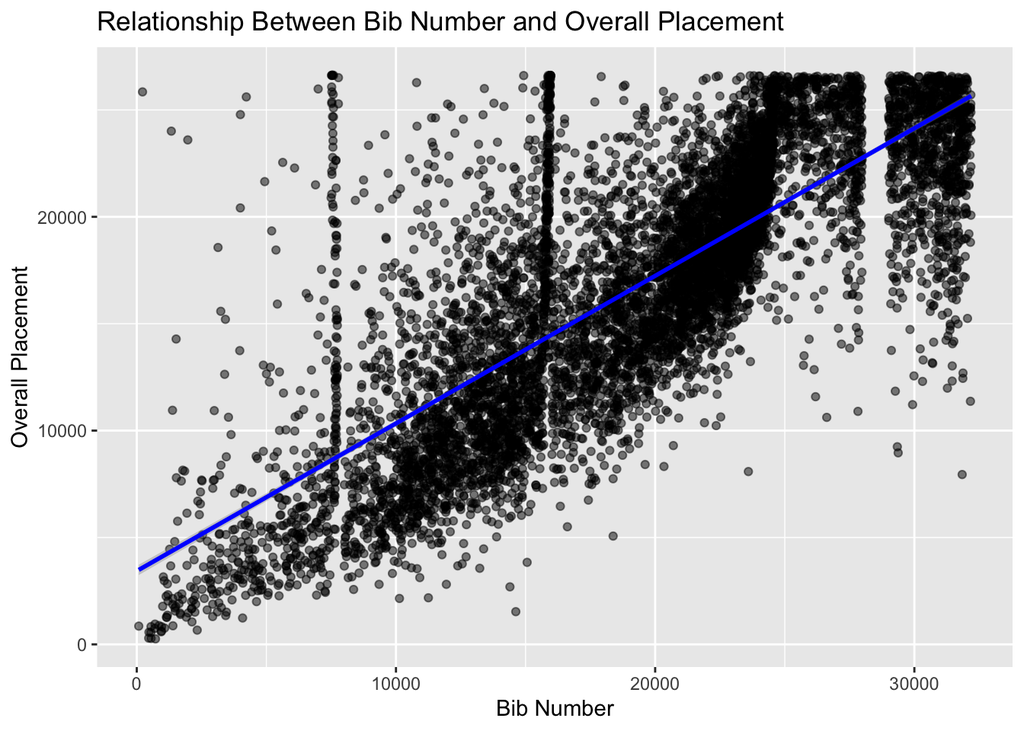

```r
ggplot(filtered_data, aes(x = bib_number, y = place_overall)) +
  geom_point(alpha = 0.5) +
  geom_smooth(method = "lm", color = "blue") +
  labs(title = "Relationship Between Bib Number and Overall Placement",
       x = "Bib Number", y = "Overall Placement")
```

Here we can clearly see a positive linear relationship between bib numbers and overall placement of runners. It also tells us that bib number doesn’t exactly predict performance as we see noticeable gaps and outliers in the graph particularly towards the middle.

It may be quite challenging to interpret the graph however so we can try to simplify it by taking a sample of racers so it’s not as clustered but still enough to draw a conclusion:

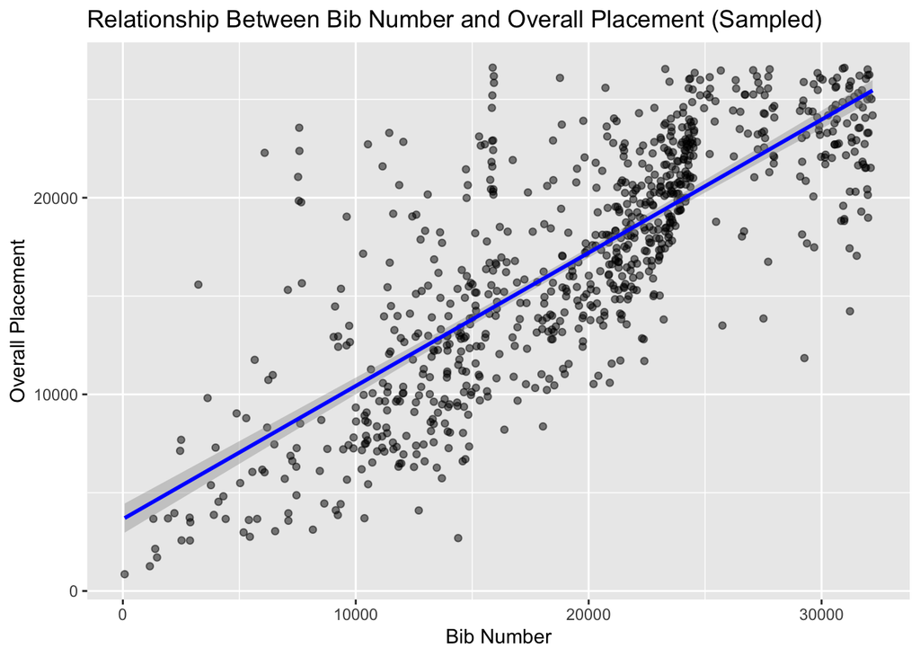

```r
library(dplyr)

# Here we'll randomly sample 10% from each group
sampled_data <- filtered_data %>%
  sample_frac(0.1)

# Create the graph with the sample
library(ggplot2)
ggplot(sampled_data, aes(x = bib_number, y = place_overall)) +
  geom_point(alpha = 0.5) +
  geom_smooth(method = "lm", color = "blue") +
  labs(title = "Relationship Between Bib Number and Overall Placement (Sampled)",
       x = "Bib Number", y = "Overall Placement")
```

Being much easier to interpret we still observe the same results and come to the same conclusion. Lower bib numbers are accociated with those who are more likely to do better in performance than compared to those who have higher bib numbers.

Theres a noticeable gap right before 30,000 which could call for more observation:

```r
# Filter data for bib numbers near the gap
gap_data <- filtered_data %>%
  filter(bib_number > 27000 & bib_number < 31000)

summary(gap_data)
```

```
##    age_group   place_overall    place_gender   place_division
##  50-54  :366   Min.   : 8960   Min.   : 1626   Min.   :  28
##  55-59  :229   1st Qu.:21480   1st Qu.:10673   1st Qu.: 758
##  60-64  :130   Median :23656   Median :12647   Median :1116
##  65-69  : 48   Mean   :22950   Mean   :12269   Mean   :1143
##  70-74  : 21   3rd Qu.:25358   3rd Qu.:14154   3rd Qu.:1572
##  75-79  :  2   Max.   :26613   Max.   :15168   Max.   :2048
##  (Other):  0
##      name               team             bib_number     half_time
##  Length:796         Length:796         Min.   :27005   Length:796
##  Class :character   Class :character   1st Qu.:27852   Class :character
##  Mode  :character   Mode  :character   Median :29530   Mode  :character
##                                        Mean   :29273
##                                        3rd Qu.:30362
##                                        Max.   :30990
##
##   finish_net         finish_gun           gender          half_time_sec
##  Length:796         Length:796         Length:796         Min.   : 5792
##  Class :character   Class :character   Class :character   1st Qu.: 7342
##  Mode  :character   Mode  :character   Mode  :character   Median : 7986
##                                                           Mean   : 8059
##                                                           3rd Qu.: 8686
##                                                           Max.   :10959
##                                                           NA's   :2
##  finish_net_sec  finish_gun_sec  finish_net_minutes finish_net_seconds
##  Min.   :11956   Min.   :11956   Min.   :199.3      Min.   :11956
##  1st Qu.:15401   1st Qu.:15636   1st Qu.:256.7      1st Qu.:15401
##  Median :16892   Median :17197   Median :281.5      Median :16892
##  Mean   :17109   Mean   :17364   Mean   :285.2      Mean   :17109
##  3rd Qu.:18788   3rd Qu.:19020   3rd Qu.:313.1      3rd Qu.:18788
##  Max.   :23514   Max.   :23664   Max.   :391.9      Max.   :23514
##
##  finish_net_hours
##  Min.   :3.321
##  1st Qu.:4.278
##  Median :4.692
##  Mean   :4.753
##  3rd Qu.:5.219
##  Max.   :6.532
##
```

All of the missing bib numbers from the range

```r
unique_bibs <- unique(filtered_data$bib_number)
missing_bibs <- setdiff(27000:31000, unique_bibs)
print(missing_bibs)
```

```
##    [1] 27000 27001 27002 27003 27004 27006 27007 27008 27009 27010 27011 27012
##   [13] 27013 27014 27015 27016 27017 27019 27020 27021 27022 27023 27024 27025
##   [25] 27026 27027 27028 27029 27030 27031 27032 27033 27034 27035 27036 27037
##   [37] 27038 27040 27041 27042 27043 27044 27045 27046 27047 27048 27049 27050
##   [49] 27051 27052 27053 27054 27055 27056 27057 27059 27060 27061 27062 27063
##   [61] 27065 27067 27068 27069 27072 27073 27074 27075 27077 27078 27079 27080
##   [73] 27081 27082 27083 27084 27085 27086 27087 27088 27089 27090 27091 27092
##   [85] 27093 27094 27095 27096 27097 27098 27099 27100 27101 27103 27104 27105
##   [97] 27106 27107 27109 27110 27112 27114 27115 27116 27117 27118 27119 27120
##  [109] 27121 27122 27123 27125 27126 27127 27128 27129 27131 27133 27134 27136
##  [121] 27137 27138 27139 27140 27141 27143 27144 27145 27146 27147 27148 27149
##  [133] 27150 27151 27152 27154 27156 27158 27159 27161 27162 27163 27164 27166
##  [145] 27167 27168 27170 27171 27173 27175 27176 27177 27180 27181 27182 27183
##  [157] 27185 27187 27188 27189 27190 27191 27192 27193 27195 27197 27198 27201
##  [169] 27204 27205 27206 27207 27208 27209 27210 27212 27213 27214 27215 27216
```

[output cut: 253 more lines]

Lets try to investigate the ages of this gap

```r
# Filter the dataset for bib numbers in the range 27,000 to 30,000
bib_range_data <- marathon_dataset %>%
  filter(bib_number >= 27000 & bib_number <= 30000)

age_group_summary <- bib_range_data %>%
  group_by(age_group) %>%
  summarize(Count = n())

print(age_group_summary)
```

```
## # A tibble: 9 × 2
##   age_group Count
##   <fct>     <int>
## 1 18-39       985
## 2 40-44       316
## 3 45-49       257
## 4 50-54       245
## 5 55-59       151
## 6 60-64        84
## 7 65-69        32
## 8 70-74        12
## 9 75-79         1
```

[figure not shown]

```r
# Lets try to visualize this
library(ggplot2)
ggplot(age_group_summary, aes(x = age_group, y = Count, fill = age_group)) +
  geom_bar(stat = "identity") +
  labs(title = "Age Group Distribution for Bib Numbers 27,000-33,000",
       x = "Age Group", y = "Count") +
  theme_minimal() +
  theme(axis.text.x = element_text(angle = 45, hjust = 1))
```

We know that via the Boston Athletic Association that there are about 2,500 charity runners for the event. Many of these charities employ the help of young recreational runners that wouldn’t necessarily need to submit a qualifying time.

Finally lets investigate the outliers present before 10,000 and at around 15,000

```r
# Filter for bib numbers below 10,000 and around 15,000
outliers <- marathon_dataset %>%
  filter((bib_number < 10000 & place_overall < 5000) | (bib_number > 14000 & bib_number < 16000))

summary(outliers)
```

```
##    age_group   place_overall    place_gender   place_division
##  18-39  :784   Min.   :    1   Min.   :    1   Min.   :   1.0
##  50-54  :380   1st Qu.: 9172   1st Qu.: 2195   1st Qu.: 426.8
##  55-59  :237   Median :11832   Median : 4910   Median : 949.0
##  40-44  :168   Mean   :12328   Mean   : 5742   Mean   :1136.8
##  60-64  :118   3rd Qu.:15602   3rd Qu.: 8952   3rd Qu.:1571.2
##  45-49  :104   Max.   :26616   Max.   :15171   Max.   :4882.0
##  (Other): 93
##      name               team            bib_number         half_time
##  Length:1884        Length:1884        Length:1884        Length:1884
##  Class :character   Class :character   Class :character   Class :character
##  Mode  :character   Mode  :character   Mode  :character   Mode  :character
##
##
##
##
##   finish_net         finish_gun           gender          half_time_sec
##  Length:1884        Length:1884        Length:1884        Min.   : 3740
##  Class :character   Class :character   Class :character   1st Qu.: 5904
##  Mode  :character   Mode  :character   Mode  :character   Median : 6099
##                                                           Mean   : 6215
##                                                           3rd Qu.: 6372
##                                                           Max.   :11664
##                                                           NA's   :7
##  finish_net_sec  finish_gun_sec  finish_net_minutes finish_net_seconds
##  Min.   : 7554   Min.   : 7554   Min.   :125.9      Min.   : 7554
##  1st Qu.:11995   1st Qu.:12266   1st Qu.:199.9      1st Qu.:11995
##  Median :12518   Median :12802   Median :208.6      Median :12518
##  Mean   :12864   Mean   :13123   Mean   :214.4      Mean   :12864
##  3rd Qu.:13358   3rd Qu.:13642   3rd Qu.:222.6      3rd Qu.:13358
##  Max.   :23865   Max.   :24184   Max.   :397.8      Max.   :23865
##
##  finish_net_hours
##  Min.   :2.098
##  1st Qu.:3.332
##  Median :3.477
##  Mean   :3.573
##  3rd Qu.:3.710
##  Max.   :6.629
##
```

Here it tells us a bit the nature of these outliers: - Minimum finish times are 125.9 minutes - The average finish time is 214.4 minutes - The overall placement being analyzed here is from 1 to 26,616

One thing to note is the scenario that high bib numbers actually perform better than what their number gives them credit for. This should be investigated:

```r
# Filter for top performers with high bib_numbers
top_performers_high_bib <- outliers %>%
  filter(bib_number > 9000 & place_overall < 5000) %>%
  select(place_overall, bib_number, finish_net_minutes)

print(top_performers_high_bib)
```

```
## [1] place_overall      bib_number         finish_net_minutes
## <0 rows> (or 0-length row.names)
```

Split times can also be something we look at to see where people will become fatigued in the race. Here we can put aid stations so that the runners may receive water, protein bars, and other forms of aid so they can continue on to the finish:

```r
# Get the average half time for each age group
mean_half_time_by_age <- marathon_dataset %>%
  group_by(age_group) %>%
  summarise(mean_half_time_sec = mean(half_time_sec, na.rm = TRUE)) %>%
  arrange(age_group)

print(mean_half_time_by_age)
```

```
## # A tibble: 10 × 2
##    age_group mean_half_time_sec
##    <fct>                  <dbl>
##  1 18-39                  6118.
##  2 40-44                  6236.
##  3 45-49                  6397.
##  4 50-54                  6614.
##  5 55-59                  6804.
##  6 60-64                  7040.
##  7 65-69                  7353.
##  8 70-74                  7827.
##  9 75-79                  8354.
## 10 80+                    8429.
```

## Majority of the runners seem to have a half way time of 106.88 minutes or 1.78 hours. We can use this to decide where the aid station will go.

## K-Means Clustering: Performance Groups

### Question:

Can we identify distinct groups of runners based on their performance (finish time) and bib numbers, and how do these groups reflect the qualification and participation characteristics of the Boston Marathon?

### Purpose of K-Means in This Context:

- To segment runners into meaningful groups (clusters) based on their performance metrics.
- To explore relationships between bib numbers (indicative of qualification level) and finish times.
- To identify patterns in runner performance, including differences between elite, competitive, and recreational participants.

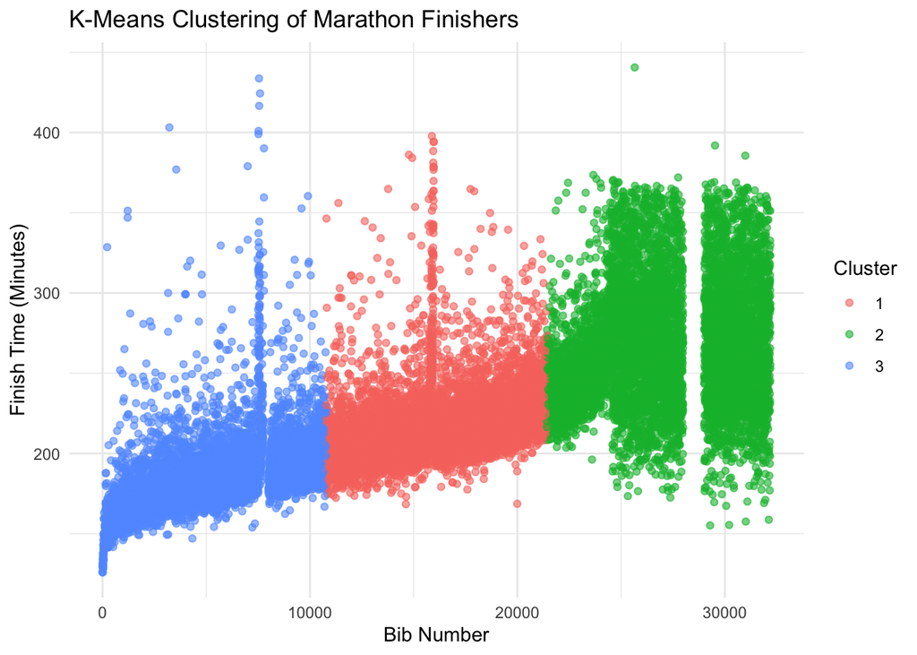

```r
# Load necessary libraries
library(ggplot2)
library(dplyr)

# Check for missing or invalid values in relevant columns
marathon_dataset$bib_number_numeric <- as.numeric(as.character(marathon_dataset$bib_number))
# Remove rows with invalid values in `bib_number_numeric`
clean_marathon_data <- marathon_dataset %>%
  filter(!is.na(bib_number_numeric))

# Prepare data for clustering
clustering_data <- clean_marathon_data[, c("finish_net_minutes", "bib_number_numeric")]

# Perform K-Means clustering
set.seed(123)
kmeans_model <- kmeans(clustering_data, centers = 3, nstart = 25)

# Add cluster assignments to the dataset
clean_marathon_data$cluster <- as.factor(kmeans_model$cluster)

# Scatter plot of clustering results
ggplot(clean_marathon_data, aes(x = bib_number_numeric, y = finish_net_minutes, color = cluster)) +
  geom_point(alpha = 0.6) +
  labs(
    title = "K-Means Clustering of Marathon Finishers",
    x = "Bib Number",
    y = "Finish Time (Minutes)",
    color = "Cluster"
  ) +
  theme_minimal()
```

### Key Insights from the K-Means Clustering Plot:

1. Clear Performance Groups:
- Cluster 3 (Blue): Represents elite runners with low bib numbers and fast finish times.
- Cluster 1 (Red): Represents competitive but non-elite runners with medium bib numbers and medium finish times.
- Cluster 2 (Green): Represents recreational or charity runners with high bib numbers and slower finish times. Relationship Between Bib Numbers and Finish Times:
2. Lower bib numbers generally correspond to faster finish times. Higher bib numbers are associated with slower times, reflecting the Boston Marathon’s qualification system. Overlap and Outliers:
3. Some runners in Cluster 2 (Green) perform exceptionally well, overlapping with Cluster 1 (Red) and Cluster 3 (Blue), suggesting high-performing recreational runners.

## Principal Component Analysis (PCA)

### Question:

Can we reduce the dimensions of the dataset to identify the most important factors influencing marathon performance, and how are finish times, bib numbers, and placements related?”

### Purpose of PCA*

Principal Component Analysis (PCA) is used to reduce the dimensionality of the dataset while retaining the most important information. It helps identify patterns and relationships between variables, such as finish times, bib numbers, and placements, by finding new uncorrelated components (principal components) that explain the maximum variance.

```r
# Select relevant numeric variables for PCA
pca_data <- clean_marathon_data[, c("finish_net_minutes", "place_overall", "bib_number_numeric")]

# Perform PCA
pca_result <- prcomp(pca_data, scale. = TRUE)

# Summary of PCA results
summary(pca_result)
```

```
## Importance of components:
##                           PC1     PC2     PC3
## Standard deviation     1.6500 0.48433 0.20679
## Proportion of Variance 0.9075 0.07819 0.01425
## Cumulative Proportion  0.9075 0.98575 1.00000
```

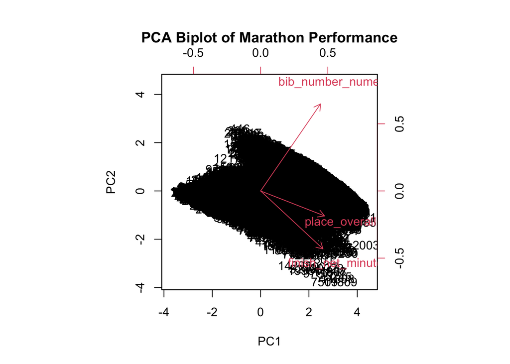

```r
# Visualize PCA with a biplot
biplot(pca_result, scale = 0, main = "PCA Biplot of Marathon Performance")
```

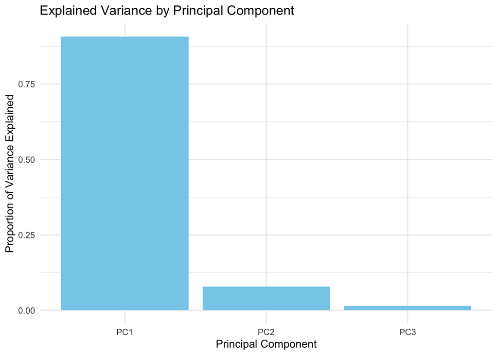

```r
# Extract and visualize the explained variance
explained_variance <- pca_result$sdev^2 / sum(pca_result$sdev^2)
explained_variance_df <- data.frame(
  Principal_Component = paste0("PC", 1:length(explained_variance)),
  Variance_Explained = explained_variance
)

# Plot explained variance
ggplot(explained_variance_df, aes(x = Principal_Component, y = Variance_Explained)) +
  geom_bar(stat = "identity", fill = "skyblue") +
  labs(
    title = "Explained Variance by Principal Component",
    x = "Principal Component",
    y = "Proportion of Variance Explained"
  ) +
  theme_minimal()
```